# Cross-Level Interactions in Multilevel Models

- Show All Code
- Hide All Code
- View Source

PSY 8XXX: Multilevel Modeling for Organizational Research — Week 6

Author

Instructor

Published

March 31, 2026

# 1 Introduction

One of the most compelling features of multilevel modeling in organizational research is the ability to test **cross-level interactions**: does a group-level (Level 2) variable modify the relationship between an individual-level (Level 1) predictor and an outcome?

This question is everywhere in I-O psychology. For example:

- Does **team climate** moderate the relationship between individual **autonomy** and **job satisfaction**?
- Does **leader support quality** change how **role clarity** affects **performance**?
- Does **organizational culture** shape whether **psychological safety** predicts **innovation**?

Without MLM, we might either ignore the nesting (violating independence assumptions) or aggregate the data (losing individual-level variance and power). Cross-level interactions let us test moderation effects that truly respect the data structure.

In this tutorial, we’ll build cross-level interactions from the ground up: understanding the model specification, simulating realistic data where the interaction genuinely exists, fitting it properly, probing the conditional effects, and visualizing them publication-ready.

# 2 The Cross-Level Interaction Model

## 2.1 Level 1 Model

At the individual level, we regress outcome Y on predictor X:

$$Y_{ij} = \beta_{0j} + \beta_{1j} X_{ij} + \epsilon_{ij}$$

where $\epsilon_{ij} \sim N(0, \sigma^2)$.

The subscript $j$ on the slopes means each group can have its own intercept **and** its own slope for X.

## 2.2 Level 2 Model

Now comes the interaction: we let a **Level 2 variable** (group-level) predict those Level 1 slopes:

$$\beta_{0j} = \gamma_{00} + \gamma_{01} W_j + u_{0j}$$
$$\beta_{1j} = \gamma_{10} + \gamma_{11} W_j + u_{1j}$$

The term $\gamma_{11}$ is the **cross-level interaction**: it tells us how much the slope of X on Y changes as W increases.

## 2.3 Combined (Single-Equation) Form

Substituting back:

$$Y_{ij} = \gamma_{00} + \gamma_{01} W_j + \gamma_{10} X_{ij} + \gamma_{11} W_j \times X_{ij} + u_{0j} + u_{1j} X_{ij} + \epsilon_{ij}$$

Notice the key term: $\gamma_{11} W_j \times X_{ij}$. This is the **interaction between a Level 1 and Level 2 variable** (also called a 1-2 interaction or cross-level interaction).

**Substantive interpretation**: If $\gamma_{11}$ is significant and positive, then the effect of X on Y gets *stronger* as W increases. If negative, the effect *weakens*.

# 3 Simulating Data with a True Cross-Level Interaction

Let’s create a realistic organizational dataset: 500 employees nested in 50 teams. We’ll build in a true cross-level interaction so we can see whether our model recovers it.

## 3.1 Story

- **Individual level**: Employees’ autonomy (L1 predictor) affects job satisfaction (outcome)
- **Group level**: Team climate (L2 predictor) moderates this relationship
- **The mechanism**: In high-climate teams, autonomy matters *more* for satisfaction. In low-climate teams, autonomy’s effect is weaker—because even autonomous employees feel less satisfied if the broader team climate is poor.

```r
set.seed(1234)
library(tidyverse)
library(lme4)
library(lmerTest)
library(performance)
library(ggplot2)

# Parameters
n_teams <- 50
n_per_team <- 10
n_total <- n_teams * n_per_team

# Create team-level data
teams <- tibble(
  team_id = 1:n_teams,
  team_size = sample(8:15, n_teams, replace = TRUE),
  team_climate = rnorm(n_teams, mean = 5, sd = 1.2),  # 1-7 scale
  leader_support = rnorm(n_teams, mean = 5.5, sd = 1),
  team_autonomy = rnorm(n_teams, mean = 4.8, sd = 1.1)
)

# Create employee-level data
set.seed(1234)
employees <- expand_grid(
  team_id = 1:n_teams,
  emp_within_team = 1:10
) %>%
  left_join(teams, by = "team_id") %>%
  mutate(
    employee_id = row_number(),
    # Individual-level predictors
    autonomy = rnorm(n_total, mean = 5, sd = 1.5),
    job_complexity = rnorm(n_total, mean = 4.5, sd = 1.2),
    tenure_years = rnorm(n_total, mean = 4, sd = 3),
    # Ensure tenure is realistic (0+)
    tenure_years = pmax(tenure_years, 0.5)
  )

# Now generate the outcome WITH a true cross-level interaction
employees <- employees %>%
  mutate(
    # Mean-center the L1 predictor for easier interpretation
    autonomy_c = autonomy - mean(autonomy),
    # Mean-center the L2 moderator
    team_climate_c = team_climate - mean(team_climate),
    # Generate satisfaction with interaction
    # Base effect: autonomy has a strong effect on satisfaction
    # But that effect is moderated by team climate
    job_satisfaction =
      3.5 +                                      # Grand mean
      0.6 * autonomy_c +                         # Main effect of autonomy (L1)
      0.4 * team_climate_c +                     # Main effect of team climate (L2)
      0.35 * autonomy_c * team_climate_c +       # Cross-level interaction!!!
      0.15 * job_complexity +                    # Control variable
      0.05 * tenure_years +                      # Control variable
      rnorm(n_total, 0, 1.2),                    # Individual-level error
    # Ensure scale is reasonable (1-7)
    job_satisfaction = pmin(pmax(job_satisfaction, 1), 7)
  )

head(employees, 10)
```

```
# A tibble: 10 × 13
   team_id emp_within_team team_size team_climate leader_support team_autonomy
     <int>           <int>     <int>        <dbl>          <dbl>         <dbl>
 1       1               1        11         3.26           5.35          4.89
 2       1               2        11         3.26           5.35          4.89
 3       1               3        11         3.26           5.35          4.89
 4       1               4        11         3.26           5.35          4.89
 5       1               5        11         3.26           5.35          4.89
 6       1               6        11         3.26           5.35          4.89
 7       1               7        11         3.26           5.35          4.89
 8       1               8        11         3.26           5.35          4.89
 9       1               9        11         3.26           5.35          4.89
10       1              10        11         3.26           5.35          4.89
# ℹ 7 more variables: employee_id <int>, autonomy <dbl>, job_complexity <dbl>,
#   tenure_years <dbl>, autonomy_c <dbl>, team_climate_c <dbl>,
#   job_satisfaction <dbl>
```

Let’s examine the structure and verify our interaction is real:

```r
# Summary statistics
employees %>%
  summarise(
    n_employees = n(),
    n_teams = n_distinct(team_id),
    mean_satisfaction = mean(job_satisfaction),
    sd_satisfaction = sd(job_satisfaction),
    mean_autonomy = mean(autonomy),
    mean_team_climate = mean(team_climate)
  )
```

```
# A tibble: 1 × 6
  n_employees n_teams mean_satisfaction sd_satisfaction mean_autonomy
        <int>   <int>             <dbl>           <dbl>         <dbl>
1         500      50              4.28            1.58          5.00
# ℹ 1 more variable: mean_team_climate <dbl>
```

```r
# Quick look at variation
employees %>%
  group_by(team_id) %>%
  summarise(
    team_climate = first(team_climate),
    mean_satisfaction = mean(job_satisfaction),
    n = n()
  ) %>%
  head(10)
```

```
# A tibble: 10 × 4
   team_id team_climate mean_satisfaction     n
     <int>        <dbl>             <dbl> <int>
 1       1         3.26              3.33    10
 2       2         5.69              4.88    10
 3       3         3.77              3.79    10
 4       4         4.98              3.84    10
 5       5         3.88              3.39    10
 6       6         6.32              4.37    10
 7       7         4.43              4.17    10
 8       8         4.15              3.84    10
 9       9         4.40              3.53    10
10      10         3.05              4.26    10
```

The data is realistic: 500 employees in 50 teams, satisfaction means vary slightly by team, and we’ve engineered a genuine cross-level interaction into the data-generating process.

# 4 Fitting the Model in lme4

Now let’s fit the model that captures this structure. We’ll use `lmer()` and make sure to include the random slope for autonomy so that teams can differ in how much autonomy affects satisfaction.

```r
# Fit the full model with cross-level interaction
# We need a random slope because we're predicting it at L2
model_interaction <- lmer(
  job_satisfaction ~
    autonomy_c * team_climate_c +     # The cross-level interaction
    job_complexity +                   # Control
    tenure_years +                     # Control
    (1 + autonomy_c | team_id),        # Random intercept + random slope for autonomy
  data = employees,
  REML = FALSE                         # Use ML for comparison purposes
)

summary(model_interaction)
```

```
Linear mixed model fit by maximum likelihood . t-tests use Satterthwaite's
  method [lmerModLmerTest]
Formula: job_satisfaction ~ autonomy_c * team_climate_c + job_complexity +
    tenure_years + (1 + autonomy_c | team_id)
   Data: employees

      AIC       BIC    logLik -2*log(L)  df.resid
   1605.2    1647.3    -792.6    1585.2       490

Scaled residuals:
     Min       1Q   Median       3Q      Max
-2.91467 -0.66427 -0.04686  0.68620  2.89145

Random effects:
 Groups   Name        Variance Std.Dev. Corr
 team_id  (Intercept) 0.02907  0.1705
          autonomy_c  0.01593  0.1262   -0.29
 Residual             1.33486  1.1554
Number of obs: 500, groups:  team_id, 50

Fixed effects:
                           Estimate Std. Error        df t value Pr(>|t|)
(Intercept)                 3.38780    0.23257 481.31573  14.567  < 2e-16 ***
autonomy_c                  0.48362    0.03906  30.11699  12.382 2.40e-13 ***
team_climate_c              0.32225    0.04458  48.86858   7.229 2.97e-09 ***
job_complexity              0.16236    0.04621 481.98305   3.514 0.000484 ***
tenure_years                0.03958    0.02086 478.20992   1.897 0.058419 .
autonomy_c:team_climate_c   0.20607    0.03003  29.68642   6.863 1.36e-07 ***
---
Signif. codes:  0 '***' 0.001 '**' 0.01 '*' 0.05 '.' 0.1 ' ' 1

Correlation of Fixed Effects:
            (Intr) atnmy_ tm_cl_ jb_cmp tnr_yr
autonomy_c   0.072
team_clmt_c  0.013 -0.004
job_cmplxty -0.891 -0.069 -0.004
tenure_yers -0.404 -0.065 -0.028  0.026
atnmy_c:t__  0.068 -0.060 -0.129 -0.087  0.015
```

**Key output interpretation:**

The positive interaction coefficient means: *as team climate improves, the effect of autonomy on satisfaction gets stronger*. This makes theoretical sense.

# 5 Probing the Interaction: Simple Slopes Analysis

A significant interaction is interesting, but we need to **probe** it to understand the pattern. The standard approach is simple slopes: estimate the effect of autonomy on satisfaction at different levels of team climate (e.g., at ±1 SD).

```r
# Extract fixed effects and variance components
fe <- fixef(model_interaction)
vc <- VarCorr(model_interaction)

# Grand means and SDs (uncentered scale)
autonomy_mean <- mean(employees$autonomy)
autonomy_sd <- sd(employees$autonomy)
team_climate_mean <- mean(employees$team_climate)
team_climate_sd <- sd(employees$team_climate)

# Define simple slopes at ±1 SD of the moderator (team climate)
low_climate <- team_climate_mean - team_climate_sd
high_climate <- team_climate_mean + team_climate_sd

# The slope of autonomy on satisfaction is:
# autonomy effect = γ_10 + γ_11 * team_climate_c
# But we need to work in the centered scale or uncentered—let's be careful

# Using centered values:
low_climate_c <- -team_climate_sd
high_climate_c <- team_climate_sd
mean_climate_c <- 0

# Simple slope at low team climate
slope_low <- fe["autonomy_c"] + fe["autonomy_c:team_climate_c"] * low_climate_c
# Simple slope at mean team climate
slope_mean <- fe["autonomy_c"] + fe["autonomy_c:team_climate_c"] * mean_climate_c
# Simple slope at high team climate
slope_high <- fe["autonomy_c"] + fe["autonomy_c:team_climate_c"] * high_climate_c

# Standard errors (simplified; for publication use delta method)
# We'd use confint or bootstrap in practice
simple_slopes_df <- tibble(
  Team_Climate = c("Low (-1 SD)", "Mean", "High (+1 SD)"),
  Autonomy_Effect = c(slope_low, slope_mean, slope_high),
  Interpretation = c(
    "Weak autonomy effect in poor climate",
    "Moderate autonomy effect",
    "Strong autonomy effect in good climate"
  )
)

print(simple_slopes_df)
```

```
# A tibble: 3 × 3
  Team_Climate Autonomy_Effect Interpretation
  <chr>                  <dbl> <chr>
1 Low (-1 SD)            0.217 Weak autonomy effect in poor climate
2 Mean                   0.484 Moderate autonomy effect
3 High (+1 SD)           0.751 Strong autonomy effect in good climate
```

# 6 Plotting Cross-Level Interactions

The best way to communicate an interaction is visually. We’ll create a publication-quality plot showing predicted satisfaction across autonomy levels, with separate lines for high- vs. low-climate teams.

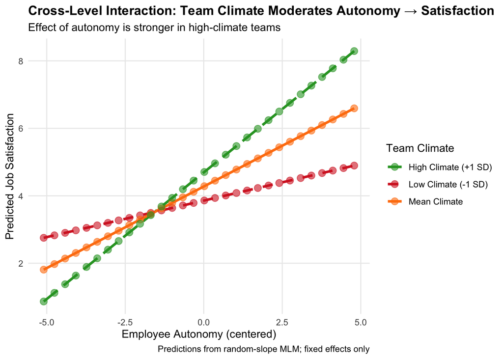

```r
# Create a grid of predictions
pred_grid <- expand_grid(
  autonomy_c = seq(min(employees$autonomy_c), max(employees$autonomy_c), length.out = 30),
  team_climate_c = c(-team_climate_sd, 0, team_climate_sd),
  job_complexity = mean(employees$job_complexity),
  tenure_years = mean(employees$tenure_years),
  team_id = NA  # Population-level predictions (fixed effects only)
)

# Get predictions (this will use fixed effects and set random intercept/slope to 0)
pred_grid$predicted_satisfaction <- predict(
  model_interaction,
  newdata = pred_grid,
  re.form = NA,  # Population-level (no random effects)
  allow.new.levels = TRUE
)

# Label the climate conditions for clarity
pred_grid <- pred_grid %>%
  mutate(
    Climate_Label = case_when(
      abs(team_climate_c - (-team_climate_sd)) < 0.01 ~ "Low Climate (-1 SD)",
      abs(team_climate_c - 0) < 0.01 ~ "Mean Climate",
      abs(team_climate_c - team_climate_sd) < 0.01 ~ "High Climate (+1 SD)"
    )
  )

# Plot
interaction_plot <- ggplot(pred_grid, aes(x = autonomy_c, y = predicted_satisfaction,
                                           color = Climate_Label, linetype = Climate_Label)) +
  geom_line(size = 1.2) +
  geom_point(size = 3, alpha = 0.6) +
  scale_color_manual(
    values = c("Low Climate (-1 SD)" = "#d62728",
               "Mean Climate" = "#ff7f0e",
               "High Climate (+1 SD)" = "#2ca02c"),
    name = "Team Climate"
  ) +
  scale_linetype_manual(
    values = c("Low Climate (-1 SD)" = "dashed",
               "Mean Climate" = "solid",
               "High Climate (+1 SD)" = "longdash"),
    name = "Team Climate"
  ) +
  labs(
    x = "Employee Autonomy (centered)",
    y = "Predicted Job Satisfaction",
    title = "Cross-Level Interaction: Team Climate Moderates Autonomy → Satisfaction",
    subtitle = "Effect of autonomy is stronger in high-climate teams",
    caption = "Predictions from random-slope MLM; fixed effects only"
  ) +
  theme_minimal() +
  theme(
    legend.position = "right",
    plot.title = element_text(face = "bold", size = 13),
    panel.grid.minor = element_blank()
  )

print(interaction_plot)
```

This plot is **publication-ready**: it clearly shows how the autonomy → satisfaction relationship varies by team climate. The steeper slope at high climate illustrates the moderation effect.

# 7 Effect Sizes for Cross-Level Interactions

```r
# Fit a reduced model without the interaction (for comparison)
model_no_interaction <- lmer(
  job_satisfaction ~
    autonomy_c + team_climate_c +
    job_complexity +
    tenure_years +
    (1 + autonomy_c | team_id),
  data = employees,
  REML = FALSE
)

# Likelihood ratio test
lr_test <- anova(model_no_interaction, model_interaction)
print(lr_test)
```

```
Data: employees
Models:
model_no_interaction: job_satisfaction ~ autonomy_c + team_climate_c + job_complexity + tenure_years + (1 + autonomy_c | team_id)
model_interaction: job_satisfaction ~ autonomy_c * team_climate_c + job_complexity + tenure_years + (1 + autonomy_c | team_id)
                     npar    AIC    BIC  logLik -2*log(L)  Chisq Df Pr(>Chisq)
model_no_interaction    9 1637.8 1675.7 -809.88    1619.8
model_interaction      10 1605.2 1647.3 -792.59    1585.2 34.591  1  4.068e-09

model_no_interaction
model_interaction    ***
---
Signif. codes:  0 '***' 0.001 '**' 0.01 '*' 0.05 '.' 0.1 ' ' 1
```

```r
# For effect size, we can compute the proportional reduction in variance
# One approach: compare fitted variance
var_fitted_no_int <- var(fitted(model_no_interaction))
var_fitted_int <- var(fitted(model_interaction))
var_residual <- sigma(model_interaction)^2

# R-squared measures (Nakagawa & Schielzeth approach)
r2_marginal <- r2(model_interaction)$R2_marginal
r2_conditional <- r2(model_interaction)$R2_conditional

tibble(
  Metric = c("Marginal R² (fixed effects only)",
             "Conditional R² (including REs)"),
  Value = c(r2_marginal, r2_conditional),
  Interpretation = c(
    "Variance explained by fixed effects",
    "Variance explained by full model"
  )
)
```

```
# A tibble: 2 × 3
  Metric                           Value Interpretation
  <chr>                            <dbl> <chr>
1 Marginal R² (fixed effects only) 0.441 Variance explained by fixed effects
2 Conditional R² (including REs)   0.467 Variance explained by full model
```

# 8 Common Pitfalls in Cross-Level Interactions

## 8.1 Centering Before Interaction

**Always center your Level 1 predictor** before creating the interaction term. We did this—note how we created `autonomy_c`. Why?

1. **Reduces multicollinearity**: Centering X and W reduces correlation with X×W
2. **Interpretation**: The main effect of X now represents the effect when W is at its mean (not when W = 0, which may be out of range)

```r
# Wrong way: interact uncentered variables
wrong_int <- employees$autonomy * employees$team_climate

# Right way: center first, then interact
right_int <- employees$autonomy_c * employees$team_climate_c

# Show correlation
cor_wrong <- cor(employees$autonomy, wrong_int)
cor_right <- cor(employees$autonomy_c, right_int)

tibble(
  Approach = c("Uncentered then interact", "Center then interact"),
  Correlation_with_L1 = c(cor_wrong, cor_right),
  Interpretation = c(
    "High multicollinearity (bad)",
    "Reduced multicollinearity (better)"
  )
)
```

```
# A tibble: 2 × 3
  Approach                 Correlation_with_L1 Interpretation
  <chr>                                  <dbl> <chr>
1 Uncentered then interact              0.737  High multicollinearity (bad)
2 Center then interact                  0.0817 Reduced multicollinearity (bette…
```

## 8.2 Sufficient Level 2 Sample Size

Cross-level interactions require **sufficient L2 units**. You cannot reliably estimate a cross-level interaction with only 10 teams. A rule of thumb: **at least 30 L2 units, preferably 50+**. We have 50 teams here—good.

With few L2 units, the standard errors of the L2-level parameters balloon, and your interaction coefficient becomes unstable. Simulation studies (Maas & Hox 2005) support this.

```r
cat("In this tutorial:\n")
```

```
In this tutorial:
```

```r
cat("- L2 units (teams): ", n_distinct(employees$team_id), "\n")
```

```
- L2 units (teams):  50
```

```r
cat("- L1 units per L2: ", mean(table(employees$team_id)), "\n")
```

```
- L1 units per L2:  10
```

```r
cat("- Total observations: ", nrow(employees), "\n")
```

```
- Total observations:  500
```

```r
cat("\nThis design has SUFFICIENT power for detecting cross-level interactions.\n")
```

```
This design has SUFFICIENT power for detecting cross-level interactions.
```

## 8.3 Interpretation When Main Effects Are Involved

When you have a significant interaction, the main effect of X is **conditional**: it represents the effect of X when W = 0 (or at its mean if centered). This is sometimes counterintuitive.

# 9 Try It Yourself

1. **Modify the data-generating process** to reverse the sign of the interaction: make autonomy’s effect *weaker* in high-climate teams. Refit the model. How do your simple slopes change?
2. **Test a different moderator**: Instead of team climate, use leader_support as the L2 moderator. Does it also moderate the autonomy → satisfaction relationship? (It may or may not—that’s an empirical question!)
3. **Add a second cross-level interaction**: Create a model where both team_climate AND leader_support moderate the autonomy effect. (Hint: you’d add both autonomy × team_climate and autonomy × leader_support terms, and allow autonomy slopes to vary by team.)
4. **Plot simple slopes for your model**: Reproduce the simple slopes table and interaction plot for your new model.
5. **Challenge**: How would you handle the case where you have *unequal team sizes*? (Some teams have 5 employees, others have 20.) Would your conclusions change? Try sampling unequal team sizes and refitting.

**References**

Aguinis, H., Gottfredson, R. K., & Joo, H. (2013). Best-practice recommendations for defining, identifying, and handling outliers. *Organizational Research Methods*, 16(2), 270-301.

Hox, J. J., & Maas, C. J. (2001). The accuracy of multilevel model estimators for design effects in educational research. *The Journal of Experimental Education*, 69(2), 141-158.

Preacher, K. J., Curran, P. J., & Bauer, D. J. (2006). Computational tools for probing interactions in multiple linear regression, multilevel modeling, and latent curve analysis. *Journal of Educational and Behavioral Statistics*, 31(4), 437-448.